# drug_effects

```python
import lateral_signaling as lsig
import numpy as np
import pandas as pd
from tqdm import tqdm
import numba

import scipy.integrate as sint
from scipy.spatial import Voronoi

import holoviews as hv
import colorcet as cc
hv.extension("matplotlib")
```

```python
%load_ext blackcellmagic
```

### Define custom functions

```python
def tc_rhs_3_g(S, S_delay, Adj, sender_idx, lambda_, alpha, k, p, delta, ell, g):
    """
    Right-hand side of the transciever circuit delay
    differential equation with growth rate `g`
    """

    # Set perimeter at density = 1
    P0 = 6 / np.sqrt(3)

    # Get input signal conc. across each interface
    S_bar = ell * Adj @ S_delay / P0

    # Calculate dE/dt
    dS_dt = (
        lambda_
        + alpha
        * (S_bar ** p)
        / (
            ((g ** 2) * k) ** p
            + (delta * S_delay) ** p
            + S_bar ** p
        )
        - g * S
    )

    # Set sender cell to zero
    dS_dt[sender_idx] = 0

    return dS_dt


def get_rhs(Adj, sender_idx, func):
    """Given the indices of sender cells, returns a
    function `rhs` with call signature
    rhs(S, S_delay, *args) that can be passed to
    `lsig.integrate_DDE` and `lsig.integrate_DDE_varargs`.
    """

    def rhs(S, S_delay, *args):
        return func(S, S_delay, Adj, sender_idx, *args)

    return rhs
```

```python
def A_cells_um(nc, rho, A_c_rho1=800):
    """
    Returns the area of `nc` cells at density `rho` in
    micrometers^2.
    `A_c_rho1` is the area of each cell in micrometers^2
    at a density of rho=1.
    """
    return nc * A_c_rho1 / rho
```

### Changing degradation-dilution rate by a factor $g$

Consider a change in the degradation-dilution rate for all species $x$ to a new rate $\tilde{\gamma}_x = g \gamma_x$. Then the dynamical equation for $[S_i]$ becomes

\begin{align} \frac{\mathrm{d}\, [S_i]}{\mathrm{d} t} &= \beta_l + \beta_S \frac{\left([\overline{S_i}]_{(t-t')}\right)^p}{\left(k_s\frac{\tilde{\gamma}_F \tilde{\gamma}_N}{v \beta_N}\right)^p + \left(\delta \, [S_i]_{(t-t')}\right)^p + \left([\overline{S_i}]_{(t-t')}\right)^p} - \tilde{\gamma}_S [S_i] \\[1em] \end{align}

We then re-express our dimensionless variables and parameters using the new rates.

\begin{align} \tilde{t} &= \gamma_S t = g^{-1} \tilde{\gamma}_S t \\[1em] s_i &= \frac{\tilde{\gamma}_S}{g \beta_N} [S_i] \\[1em] \overline{s_i} &= \frac{\tilde{\gamma}_S}{g \beta_N} [\overline{S_i}] \\[1em] \lambda &= \beta_l\,\beta_N^{-1} \\[1em] \alpha &= \beta_S\,\beta_N^{-1} \\[1em] k &= k_s \tilde{\gamma}_F \tilde{\gamma}_N \tilde{\gamma}_S\,v^{-1} \,\beta_N^{-2} \, g^{-3} \\[1em] \tau &= g^{-1} \tilde{\gamma}_S t' \\[1em] \end{align}

We then substitute to get the dynamical equation for $s_i$ in terms of $g$.

\begin{align} \frac{\mathrm{d}\, s_i}{\mathrm{d} \tilde{t}} &= \frac{\beta_l}{\beta_N} + \frac{\beta_S}{\beta_N} \frac{\left(g\frac{\beta_N}{\tilde{\gamma}_S}\,\overline{s_i}_{(\tilde{t} - \tau)}\right)^p}{\left(k_s\frac{\tilde{\gamma}_F \tilde{\gamma}_N}{v \beta_N}\right)^p + \left(g \frac{\beta_N}{\tilde{\gamma}_S}\,\delta \, {s_i}_{(\tilde{t} - \tau)}\right)^p + \left(g \frac{\beta_N}{\tilde{\gamma}_S}\,\overline{s_i}_{(\tilde{t} - \tau)}\right)^p} - \frac{\tilde{\gamma}_S}{\beta_N}[S_i]\\[1em] &= \lambda + \alpha \frac{\left(\overline{s_i}_{(\tilde{t} - \tau)}\right)^p}{g^{2p} k^p + \left(\delta \, {s_i}_{(\tilde{t} - \tau)}\right)^p + \left(\overline{s_i}_{(\tilde{t} - \tau)}\right)^p} - g s_i \end{align}

Dropping the tilde notation and using vector notation:

\begin{align} \frac{\mathrm{d}\, \vec{s}}{\mathrm{d} t} &= \lambda + \alpha \frac{\left(\vec{\overline{s}}_{(\tilde{t} - \tau)}\right)^p}{g^{2p} k^p + \left(\delta \, \vec{s}_{(\tilde{t} - \tau)}\right)^p + \left(\vec{\overline{s}}_{(\tilde{t} - \tau)}\right)^p} - g \vec{s} \end{align}

### Estimation of `g` and `rho_max` from experiment

We approximate cell growth over time by assuming that cell density $\rho$ (here dimensionless) grows at a rate according to the logistic equation

\begin{align} \frac{\mathrm{d} \,\rho}{\mathrm{d} t} &= g\,\rho\, \left(1 - \frac{\rho}{\rho_{\text{max}}}\right), \end{align}

where $g$ represents the growth rate relative to the growth rate in the untreated condition. The solution to the logistic equation is

\begin{align} \rho(t) &= \frac{\rho_0 \, \rho_\text{max}}{\rho_0 + (\rho_\text{max} - \rho_0)\, e^{-gt}}, \end{align}

where $\rho_0$ is the density at time $0$. (This is implemented below using `lsig.logistic(t, g, rho_0, rho_max)`.

From previous microscopy at high-magnification, we determined that cells filled the field of view (reached confluency) at a density of $1250 \text{ mm}^{-2}$ [ref]. We use this value as a constant of proportionality for density - i.e., at a density of $1250 \text{ mm}^{-2}$, $\rho = 1$.

For the untreated condition, we previously estimated from growth curve data that this strain saturates in growth at a density of $5000 \text{ mm}^{-2}$, or $\rho_\text{max} = 4$ [ref], and we previously showed that $g = 1$ under the assumption of a constant degradation-dilution rate at all densities [ref].

For the drug-positive conditions, we estimated these parameters by comparison to a similar growth curve [ref]. In the presence of FGF2, we estimated $\rho_\text{max} = 4$ and $g = 3/2$. In the presence of Ri, we estimated $\rho_\text{max} = 2$ and $g = 1$.

The experimental starting density was $1250 \text{ mm}^{-2}$, or $\rho_0 = 1$ for all drug conditions.

```python
# Set parameters for each drug condition
drug_params = [
    #  g  rho_0  rho_max
    (  1,     1,       4),  # drug-free
    (3/2,     1,       4),  # FGF2
    (  1,     1,       2),  # Ri
]
```

To show what these growth curves would look like, we plot them below.

```python
# Set time window to demonstrate growth
t0, tmax = 0, 5
dt_ = 0.07
t_ = np.arange(t0, tmax, dt_)

# Evaluate density at time-points
curves = np.empty((3, t_.size))
for i in range(3):
    curves[i] = lsig.logistic(t_, *drug_params[i])
```

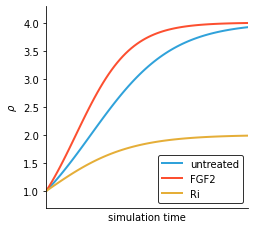

```python
%%capture --no-display

p1 = hv.Overlay(
    [
        hv.Curve(
            (t_, curves[i]),
            label = ("untreated", "FGF2", "Ri")[i]
        ).opts(
            xlabel="simulation time",
            xticks=0,
            ylabel=r"$\rho$",
        )
        for i in range(3)
    ]
)

p1
```

## Simulating signaling under different growth parameters

```python
# Make square lattice
rows = cols = 150
r = 1.   # cell-cell distance
X, Adj = lsig.hex_Adj(rows, cols, r=r, sparse=True)

# Get # cells
n = X.shape[0]
```

```python
# Assign sender(s)
# Specify percent of population that is sender
pct_s = 1
n_s = int(n * (pct_s/100)) + 1

# Set seed
np.random.seed(5)

# Assign senders randomly
sender_idx = np.random.choice(n, n_s, replace=False)

# sender_idx = lsig.get_center_cells(X, 1)
```

```python
# Get initial conditions
S0 = np.zeros(n)
S0[sender_idx] = 1

# Get RHS
rhs = get_rhs(Adj, sender_idx, tc_rhs_3_g)
```

```python
# Set time parameters
tmax = 5
nt_t = 100
nt = int(nt_t * tmax) + 1
t = np.linspace(0, tmax, nt)
```

```python
# Set signaling parameters
lambda_ = 1e-5
alpha = 3
k = 0.12
p = 2
delta = 3

# Set delay
delay = 0.4
```

The cell-cell distance $r$ is related to $\rho$ by an inverse square law.

\begin{align} r=\frac{1}{\sqrt{\rho}}. \end{align}

Assuming cells are arranged in a regular hexagonal pattern, we can solve for the cell-cell interface length.

\begin{align} \ell(t) &= \frac{r(t)}{\sqrt{3}} = \frac{1}{\sqrt{3 \rho(t)}} \end{align}

```python
# Default contact length
ell0 = r / np.sqrt(3)

# Initialize results vectors
rho_drug_t = np.empty((3, nt), dtype=np.float32)
ell_drug_t = np.empty((3, nt, n), dtype=np.float32)
X_drug_t = np.empty((3, nt, n, 2), dtype=np.float32)
S_drug_t = np.empty((3, nt, n), dtype=np.float32)

for i in range(3):

    # Get parameters
    g, rho_0, rho_max = drug_params[i]

    # Calculate density and contact length
    rho_t = lsig.logistic(t, g, rho_0, rho_max)
    r_t = 1/np.sqrt(rho_t)
    ell_t = r_t / np.sqrt(3)

    # Get cell positions
    X_t = np.empty((nt, n, 2))
    X_t[:, :, 0] = np.outer(r_t, X[:, 0])
    X_t[:, :, 1] = np.outer(r_t, X[:, 1])

    # Package parameters
    args = (lambda_, alpha, k, p, delta, ell_t[0], g)

    # Simulate
    S_t = lsig.integrate_DDE_varargs(
        t,
        rhs,
        var_vals=ell_t,
        where_vars=5,
        dde_args=args,
        E0=S0,
        delay=delay,
        min_delay=5,
    )

    # Save results
    rho_drug_t[i] = rho_t
    ell_drug_t[i] = np.outer(ell_t, np.ones(n))
    X_drug_t[i] = X_t
    S_drug_t[i] = S_t
```

```python
# Calculate area of activated cells
S_act_t = S_drug_t > k
S_act_num = S_act_t.sum(axis=2)
A_act_drug = np.array([A_cells_um(S_act_num[i], rho_drug_t[i]) for i in range(3)])
```

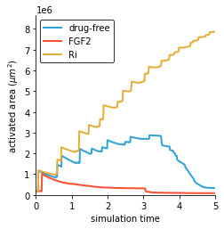

```python
%%capture --no-display

p2 = hv.Overlay(
    [
        hv.Curve(
            data = (t, A_act_drug[i]),
            label = ("drug-free", "FGF2", "Ri")[i],
        ).opts(
            xlabel = r"simulation time",
            xlim = (0, None),
            ylabel = r"activated area ($\mu m^2$)",
            ylim = (0, None),
        )
        for i in range(3)
    ]
)

p2
```

```python
zoom = 1.1
xlim = zoom * X[:, 0].min(), zoom * X[:, 0].max()
ylim = zoom * X[:, 1].min(), zoom * X[:, 1].max()

# xlim = zoom * np.array([X[:, 0].min(), X[:, 0].max()])
# ylim = zoom * np.array([X[:, 1].min(), X[:, 1].max()])
```

[figure not shown]

```python
import matplotlib.pyplot as plt
%matplotlib inline

# Set dimensions for a grid of frames
nrows, ncols = 1, 4

drug = 0

# Render frames
nplot = nrows * ncols
idx = [int(i) for i in np.linspace(0, nt-1, nplot)]
fig2, axs2 = plt.subplots(nrows=nrows, ncols=ncols, figsize=(10,6))
for ax, i in zip(axs2.flat, idx):
    title=f"Time = {t[i]:.2f}, " + r"$\rho$ = " + f"{rho_t[i]:.2f}"
    lsig.inspect_colormesh(
        ax=ax,
        X=X_drug_t[drug],
        rows=rows,
        cols=cols,
#         cell_radii=ell_drug_t[drug],
        var=S_drug_t[drug],
        idx=i,
        vmin=0,
        vmax=1,
        cmap="kgy",
        xlim=xlim,
        ylim=ylim,
        title=title,
#         plot_ifc=False,
        axis_off=True,
    )
```

[figure not shown]

```python
import matplotlib.pyplot as plt
%matplotlib inline

# Set dimensions for a grid of frames
nrows, ncols = 1, 4

drug = 1

# Render frames
nplot = nrows * ncols
idx = [int(i) for i in np.linspace(0, nt-1, nplot)]
fig2, axs2 = plt.subplots(nrows=nrows, ncols=ncols, figsize=(10,6))
for ax, i in zip(axs2.flat, idx):
    title=f"Time = {t[i]:.2f}"
    lsig.inspect_colormesh(
        ax=ax,
        X=X_drug_t[drug],
        rows=rows,
        cols=cols,
#         cell_radii=ell_drug_t[drug],
        var=S_drug_t[drug],
        idx=i,
        vmin=0,
        vmax=1,
        cmap="kgy",
        xlim=xlim,
        ylim=ylim,
        title=title,
#         plot_ifc=False,
#         axis_off=False,
    )
```

[figure not shown]

```python
import matplotlib.pyplot as plt
%matplotlib inline

# Set dimensions for a grid of frames
nrows, ncols = 1, 4

drug = 2

# Render frames
nplot = nrows * ncols
idx = [int(i) for i in np.linspace(0, nt-1, nplot)]
fig2, axs2 = plt.subplots(nrows=nrows, ncols=ncols, figsize=(10,6))
for ax, i in zip(axs2.flat, idx):
    title=f"Time = {t[i]:.2f}"
    lsig.inspect_colormesh(
        ax=ax,
        X=X_drug_t[drug],
        rows=rows,
        cols=cols,
#         cell_radii=ell_drug_t[drug],
        var=S_drug_t[drug],
        idx=i,
        vmin=0,
        vmax=1,
        cmap="kgy",
        xlim=xlim,
        ylim=ylim,
        title=title,
#         plot_ifc=False,
#         axis_off=False,
    )
```

[output not shown]

**Make parameters more precise with MLE?**

```python
import os
```

### Save plots and videos

```python
# Set directory
dir_name = "plots"

# Set filename
p2_fname = "drug_effects_{0:.1f}pctsender".format(
    pct_s
)

# Set format
fmt='png'
```

```python
%%capture --no-display

p2_path = os.path.join(dir_name, p2_fname)
hv.save(p2, p2_path, fmt=fmt, dpi=150)
```

```python
%load_ext watermark
```

```python
%watermark -v -p numpy,scipy,numba,holoviews,jupyterlab
```

```
CPython 3.7.7
IPython 7.18.1

numpy 1.18.1
scipy 1.4.1
numba 0.51.2
holoviews 1.13.2
jupyterlab 1.2.6
```